# Tarea 4: Programación funcional y distribución muestral

## Inciso 1

Descarga la carpeta specdata, ésta contiene 332 archivos csv que almacenan información de monitoreo de contaminación en 332 ubicaciones de EUA. Cada archivo contiene información de una unidad de monitoreo y el número de identificación del monitor es el nombre del archivo. En este ejercicio nos interesa unir todas las tablas en un solo data.frame que incluya el identificador de las estaciones.

La siguiente instrucción descarga los datos si trabajas con proyectos de RStudio, también puedes descargar el zip manualmente.

```r
library(usethis)
dir.create("data")
use_directory("data")
use_zip("https://d396qusza40orc.cloudfront.net/rprog%2Fdata%2Fspecdata.zip",
    destdir = "data")
```

### 1.1

Crea un vector con las direcciones de los archivos.

```r
paths <- dir("data/specdata", pattern = "\\.csv$", full.names = TRUE)
```

### 1.2

Lee uno de los archivos usando la función read_csv() del paquete readr. Tip: especifica el tipo de cada columna usando el parámetro col_types.

```r
library(readr)
prueba <- read_csv(paths[1], col_types = list(
  Date = col_date(format = ""),
  sulfate = col_double(),
  nitrate = col_double(),
  ID = col_double()
))
prueba
```

[output not shown]

### 1.3

Utiliza la función map_df() para iterar sobre el vector con las direcciones de los archivos csv y crea un data.frame con todos los datos, recuerda añadir una columna con el nombre del archivo para poder identificar la estación.

```r
library(purrr)
rama <- map_df(paths, read_csv, .id = "FILENAME")
```

```r
head(rama)
```

[output not shown]

## Inciso 2

Consideramos los datos de ENLACE edo. de México (enlace), y la columna de calificaciones de español 3o de primaria (esp_3).

```r
library(estcomp)
library(janitor)
library(dplyr)
enlace <- enlacep_2013 %>%
    clean_names() %>%
    mutate(id = 1:n()) %>%
    select(id, cve_ent, turno, tipo, esp_3 = punt_esp_3, esp_6 = punt_esp_6,
        n_eval_3 = alum_eval_3, n_eval_6 = alum_eval_6) %>%
    na.omit() %>%
    filter(esp_3 > 0, esp_6 > 0, n_eval_3 > 0, n_eval_6 > 0, cve_ent == "15")
```

### 2.1

Selecciona una muestra de tamaño  
n =10, 100, 1000 Para cada muestra calcula media y el error estándar de la media usando el principio del plug-in: Tip: Usa la función sample_n() del paquete deplyr para generar las muestras.

```r
plug_in <- function(enlace, esp_3, n) {
  enlace %>% summarise(
    media = mean(esp_3, na.rm = TRUE),
    se = sd(esp_3 , na.rm = TRUE) / sqrt(n)
  )
}
```

```r
set.seed(16021)
# muestra
enlace_10 <- sample_n(enlace, 10)
enlace_100 <- sample_n(enlace, 100)
enlace_1000 <- sample_n(enlace, 1000)
est10 <- plug_in(enlace_10, esp_3, 10)
est100 <- plug_in(enlace_100, esp_3, 100)
est1000 <-plug_in(enlace_1000, esp_3, 1000)
est10
```

| media | se |
| --- | --- |
| 545.6 | 17.71453 |

```r
est100
```

| media | se |
| --- | --- |
| 552.7 | 6.037618 |

```r
est1000
```

| media | se |
| --- | --- |
| 554.531 | 1.85981 |

### 2.2

Ahora aproximareos la distribución muestral, para cada tamaño de muestran La distribución de la estadística es la distribución muestral.

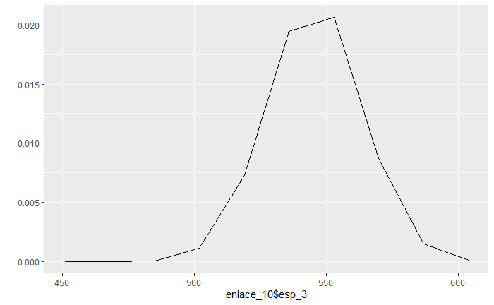

```r
library(ggplot2)
ggplot() +
  stat_function(data = enlace_10, aes(enlace_10$esp_3), fun = dnorm, n = 10, args = list(mean = est10[[1]], sd = est10[[2]])) + ylab("")
```

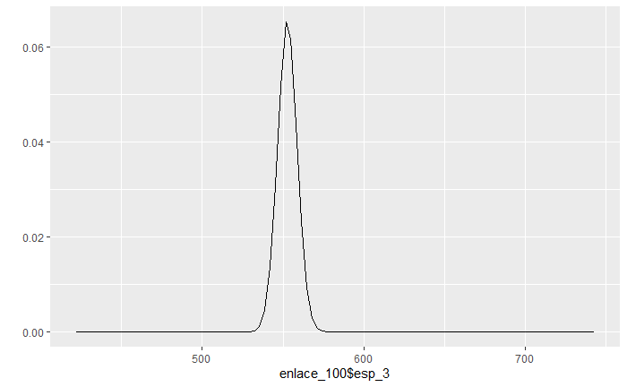

```r
ggplot() +
    stat_function(data = enlace_100, aes(enlace_100$esp_3), fun = dnorm, n = 100, args = list(mean = est100[[1]], sd = est100[[2]])) + ylab("")
```

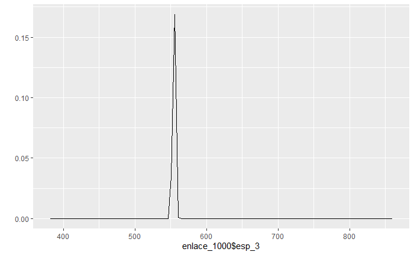

```r
 ggplot() +
    stat_function(data = enlace_1000, aes(enlace_1000$esp_3), fun = dnorm, n = 100, args = list(mean = est1000[[1]], sd = est1000[[2]])) + ylab("")
```

#### 2.2 inciso i

Simula 10,000 muestras aleatorias, ii) calcula la media en cada muestra,

```r
library(purrr)
simula_media <- function(n, x) {
  muestra_boot <- sample(x, size = n, replace = TRUE)
  mean(muestra_boot, na.rm = TRUE)
}
medias_10 <- rerun(10000, simula_media(n = 10, enlace$esp_3)) %>% flatten_dbl()
medias_100 <- rerun(10000, simula_media(n = 100, enlace$esp_3)) %>% flatten_dbl()
medias_1000 <- rerun(10000, simula_media(n = 1000, enlace$esp_3)) %>% flatten_dbl()
```